# Project 2 – Estimating the Probability of Mumbai Indians and Chennai Super Kings Reaching the Same IPL Final

## Executive Summary

The Indian Premier League (IPL) is known for its unpredictability. No matter how strong a team looks on paper, a few key moments can change the outcome of an entire season. This project explores a question that interests both fans and analysts: how often do the Mumbai Indians (MI) and Chennai Super Kings (CSK), two of the most dominant IPL franchises, reach the same final?

To answer this question, we analyzed publicly available match data from the 2019 IPL season. Each team’s performance was used to estimate its overall strength, while also accounting for the small but important advantage of batting first. These estimates were then used to simulate the entire season thousands of times. Each simulation replayed every match, including the playoffs, under realistic conditions that captured the randomness of the toss, batting order, and the short-tournament format.

Across 20,000 simulated seasons, Mumbai and Chennai both reached the final together 33.5% of the time. While both teams performed well in most simulations, the chance of seeing them face each other in the final remained modest. This reflects how much uncertainty and variation exists in the IPL, even for the strongest teams.

These results show that dominance in cricket does not guarantee deep playoff runs. Random factors such as the toss or one poor over can have a large influence on team outcomes. For coaches and analysts, this highlights the importance of maintaining lineup flexibility and focusing on controllable factors. For fans, it provides a data-driven view of how chance and structure shape the excitement of the IPL.

Future work could extend this analysis by including more seasons, adjusting for home advantage, or tracking how team strengths evolve over time. Even this single-season study shows that probabilistic modeling can turn cricket’s unpredictability into clear and measurable insight.

## Technical Report

### Introduction and Motivation

The rivalry between Mumbai Indians and Chennai Super Kings defines modern franchise cricket. Both teams have dominated over several IPL seasons, yet meeting in the final is far from guaranteed. This project measures how often both teams reached the final in 2019 using a probabilistic model and season-long simulations.

By modeling full seasons rather than individual matches, we can better understand how tournament structure, randomness, and team strength combine to produce different outcomes. This approach is useful not only to cricket analysts but also to coaches, broadcasters, and team management staff.

### Data and Preparation

We used ball-by-ball data from Cricsheet, using the cricketdata package in R. Each record contains team names, runs scored, and inning details for every delivery. The data were filtered to include only the 2019 season and aggregated to identify which team batted first and which team won. This clean match-level data formed the foundation for estimating team abilities and simulating entire seasons.

```r
bbb <- cricketdata::fetch_cricsheet("bbb", "male", "ipl")

runs_by_innings <- bbb %>%
filter(season == 2019) %>%
filter(innings %in% c(1, 2)) %>%
mutate(runs_total = runs_off_bat + extras) %>%
group_by(match_id, season, innings, batting_team, bowling_team) %>%
summarise(innings_runs = sum(runs_total, na.rm = TRUE), .groups = "drop")

first_second <- runs_by_innings %>%
arrange(match_id, innings) %>%
group_by(match_id, season) %>%
summarise(
first_batting  = batting_team[innings == 1][1],
second_batting = batting_team[innings == 2][1],
first_runs     = innings_runs[innings == 1][1],
second_runs    = innings_runs[innings == 2][1],
.groups = "drop"
) %>%
filter(!is.na(first_batting), !is.na(second_batting), !is.na(first_runs), !is.na(second_runs)) %>%
mutate(
winner = case_when(
first_runs  > second_runs ~ first_batting,
second_runs > first_runs  ~ second_batting,
TRUE ~ NA_character_
)
) %>%
filter(!is.na(winner))

m2019 <- first_second %>%
transmute(
match_id, season,
team1 = first_batting,
team2 = second_batting,
winner = winner,
firstbat_win  = as.integer(winner == team1),
secondbat_win = as.integer(winner == team2)
)
```

### Modeling Approach

To estimate team strengths, we fit a Bradley–Terry paired-comparison model that assigns each team an underlying “ability” parameter. The model assumes that the probability of one team beating another depends on the difference in their abilities and includes a term for the batting-order effect (batting first or second).

The model was trained using outcomes from the 2019 season, with Chennai Super Kings (CSK) set as the reference team. This allows all other teams’ abilities to be interpreted relative to CSK.

```r
teams_2019 <- sort(unique(c(m2019$team1, m2019$team2)))

results <- m2019 %>%
group_by(team1 = factor(team1, levels = teams_2019),
team2 = factor(team2, levels = teams_2019)) %>%
summarise(
first.win  = sum(firstbat_win),
second.win = sum(secondbat_win),
.groups = "drop"
) %>%
mutate(first.atfirst = 1L, second.atfirst = 0L)

bt_df <- data.frame(first.win = results$first.win,
second.win = results$second.win)
bt_df$first.team  <- data.frame(team = results$team1,  at.first = results$first.atfirst)
bt_df$second.team <- data.frame(team = results$team2,  at.first = results$second.atfirst)

ref_team <- teams_2019[1]

bt_fit <- BradleyTerry2::BTm(
outcome = cbind(first.win, second.win),
player1 = first.team, player2 = second.team,
formula = ~ team + at.first,
refcat  = ref_team,
id      = "team",
data    = bt_df
)

lambda_hat <- BradleyTerry2::BTabilities(bt_fit)[, "ability"]
gamma_hat  <- unname(coef(bt_fit)["at.first"])

ilogit <- function(x) 1/(1 + exp(-x))

p_A_beats_B <- function(A, B, A_first = TRUE) {
diff <- lambda_hat[A] - lambda_hat[B]
adj  <- if (isTRUE(A_first)) gamma_hat else -gamma_hat
ilogit(diff + adj)
}
```

The estimated batting-first coefficient (γ ≈ –0.48) indicates that, during 2019, batting first slightly decreased a team’s chance of winning. On the probability scale, this translates to roughly a 10–12 percentage point disadvantage when batting first, consistent with real-world trends where teams chasing targets often performed better.

The figure below illustrates how the model translated match outcomes into quantitative team strengths. By assigning each team an ability score on the logit scale, the model captures how often each team is expected to outperform others.

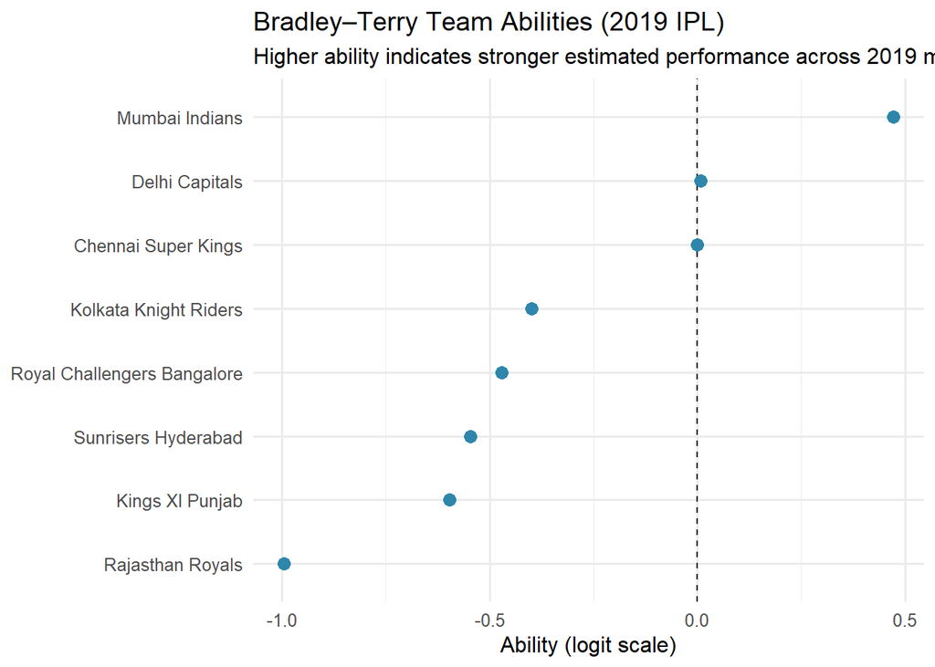

```r
ab <- BradleyTerry2::BTabilities(bt_fit)
ab_df <- as.data.frame(ab)
ab_df$team <- rownames(ab_df)

ab_df <- ab_df %>%
  mutate(team = factor(team, levels = team[order(ability)]))

ggplot(ab_df, aes(x = team, y = ability)) +
  geom_hline(yintercept = 0, linetype = "dashed") +
  geom_point(size = 3, color = "#2E86AB") +
  coord_flip() +
  labs(
    title = "Bradley–Terry Team Abilities (2019 IPL)",
    subtitle = "Higher ability indicates stronger estimated performance across 2019 matches",
    x = NULL, y = "Ability (logit scale)"
  ) +
  theme_minimal(base_size = 12)
```

The model expresses each team’s chance of winning as a logistic function of its ability difference and the batting-order effect. Specifically, the probability that Team A defeats Team B is given by:

$$P(A \text{ beats } B) = \frac{1}{1 + \exp[-(\lambda_A - \lambda_B \pm
\gamma)]}$$
where $\lambda_A$ and $\lambda_B$ are the teams’ estimated abilities and $\gamma$ represents the batting-first adjustment. A positive $\gamma$ increases the chance of winning when batting first, while a negative value favors teams chasing a target. This formulation forms the basis for the match-level probabilities used in the season simulations that follow.

### Season Simulation

1. Qualifier 1: 1st vs 2nd
2. Eliminator: 3rd vs 4th
3. Qualifier 2: Loser of Q1 vs Winner of Eliminator
4. Final: Winner of Q1 vs Winner of Q2

Each match outcome was generated by sampling from a Bernoulli trial using the modeled win probability. This allowed the simulation to incorporate both team strength and random variation arising from factors like the toss or an unexpected performance.

```r
sched2019 <- m2019 %>%
transmute(match_id, TeamA = team1, TeamB = team2, A_first = TRUE)

set.seed(479) # To ensure reproducibility

sim_one_season <- function() {
pts <- setNames(rep(0L, length(teams_2019)), teams_2019)
for (i in seq_len(nrow(sched2019))) {
A <- sched2019$TeamA[i]; B <- sched2019$TeamB[i]; A_first <- sched2019$A_first[i]
if (!(A %in% names(lambda_hat) && B %in% names(lambda_hat))) next
pA <- p_A_beats_B(A, B, A_first)
if (rbinom(1, 1, pA) == 1) pts[A] <- pts[A] + 2L else pts[B] <- pts[B] + 2L
}

ord <- order(pts, runif(length(pts)), decreasing = TRUE)
seeds <- data.frame(Team = names(pts)[ord], Points = pts[ord], Seed = seq_along(ord))
top4 <- seeds[1:4, , drop = FALSE]

Q1_A <- top4$Team[1]; Q1_B <- top4$Team[2]
Q1_p <- p_A_beats_B(Q1_A, Q1_B, A_first = (runif(1) < 0.5))
Q1_A_wins <- rbinom(1, 1, Q1_p) == 1
Q1_winner <- if (Q1_A_wins) Q1_A else Q1_B
Q1_loser  <- if (Q1_A_wins) Q1_B else Q1_A

E_A <- top4$Team[3]; E_B <- top4$Team[4]
E_p <- p_A_beats_B(E_A, E_B, A_first = (runif(1) < 0.5))
E_A_wins <- rbinom(1, 1, E_p) == 1
E_winner <- if (E_A_wins) E_A else E_B

Q2_A <- Q1_loser; Q2_B <- E_winner
Q2_p <- p_A_beats_B(Q2_A, Q2_B, A_first = (runif(1) < 0.5))
Q2_A_wins <- rbinom(1, 1, Q2_p) == 1
Q2_winner <- if (Q2_A_wins) Q2_A else Q2_B

F_A <- Q1_winner; F_B <- Q2_winner
F_p <- p_A_beats_B(F_A, F_B, A_first = (runif(1) < 0.5))
F_A_wins <- rbinom(1, 1, F_p) == 1
finalists <- sort(c(F_A, F_B))

list(top4 = top4, finalists = finalists)
}
```

### Results

Across 20,000 simulated seasons, Mumbai Indians and Chennai Super Kings reached the final together about **33.5% of the time**. This means that in roughly one out of every three simulated seasons, the two teams met in the championship match.

```r
N <- 20000
target <- c("Mumbai Indians", "Chennai Super Kings")

hits <- replicate(N, {
out <- sim_one_season()
all(target %in% out$finalists)
})

est_prob <- mean(hits)
cat(sprintf("Estimated P(MI & CSK both reach the Final) ≈ %.4f (N=%d)\n", est_prob, N))
```

```
## Estimated P(MI & CSK both reach the Final) ≈ 0.3347 (N=20000)
```

The visualization below shows how frequently each team pair reached the final in the simulations.

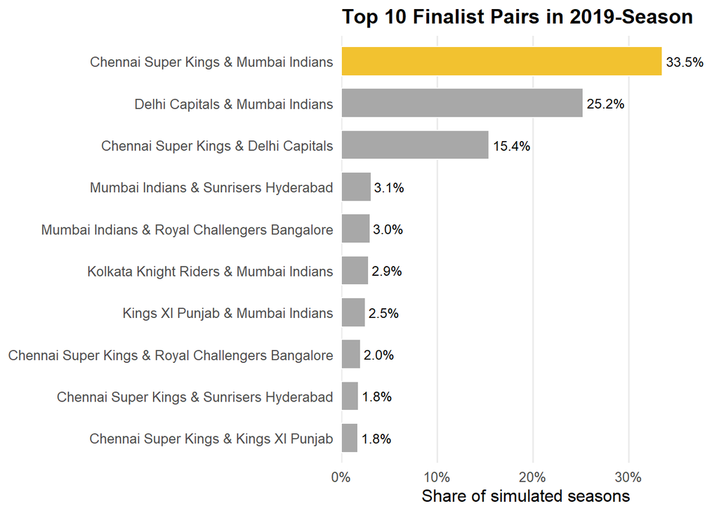

```r
set.seed(479)
S <- 20000
sim_out <- replicate(S, sim_one_season(), simplify = FALSE)

pair_keys <- vapply(sim_out, function(x) paste(sort(x$finalists), collapse = " & "), character(1))

pair_tbl <- as.data.frame(table(pair_keys), stringsAsFactors = FALSE)
colnames(pair_tbl) <- c("Pair", "Count")
pair_tbl <- pair_tbl %>% mutate(Rate = Count / S)

top_n <- 10
mi_csk_key <- paste(sort(c("Mumbai Indians", "Chennai Super Kings")), collapse = " & ")

pair_tbl_top <- pair_tbl %>%
  arrange(desc(Rate)) %>%
  slice_head(n = top_n) %>%
  mutate(
    Highlight = ifelse(Pair == mi_csk_key, "MI & CSK", "Other"),
    Pair      = fct_reorder(Pair, Rate),
    Label     = percent(Rate, accuracy = 0.1)
  )

ggplot(pair_tbl_top, aes(x = Pair, y = Rate, fill = Highlight)) +
  geom_col(width = 0.7, color = "white") +
  geom_text(aes(label = Label), hjust = -0.1, size = 3.3) +
  coord_flip() +
  scale_y_continuous(labels = percent_format(accuracy = 1), expand = expansion(mult = c(0, 0.15))) +
  scale_fill_manual(values = c("MI & CSK" = "#F2C230", "Other" = "#A8A8A8"), guide = "none") +
  labs(
    title = "Top 10 Finalist Pairs in 2019-Season",
    x = NULL, y = "Share of simulated seasons"
  ) +
  theme_minimal(base_size = 12) +
  theme(
    plot.title = element_text(face = "bold"),
    panel.grid.major.y = element_blank(),
    panel.grid.minor = element_blank()
  )
```

This figure shows that the MI–CSK pairing occurred most often, but other combinations such as Mumbai–Delhi and Chennai–Hyderabad also appeared, reflecting the inherent volatility of short tournaments. Even with clear favorites, the knockout structure and match randomness prevent any pairing from being overwhelmingly likely.

### Discussion

This type of modeling can also be applied to other sports such as baseball, basketball, or soccer to estimate playoff probabilities or test the fairness of tournament formats. The results emphasize that success depends not only on skill but also on situational factors and luck, which together make sports both unpredictable and exciting.

### Limitations and Future Work

This analysis is limited to a single IPL season (2019), which means the results may not fully reflect how teams perform across different years. Team rosters, player form, coaching strategies, and match conditions vary significantly over time. In addition, the model currently assumes a constant batting-first advantage across all teams and venues, which may simplify conditions that are more complex in reality.

Future work could expand the dataset to include multiple seasons in order to model how team strengths change over time. This would help identify long-term performance patterns instead of relying on a single season snapshot. Another improvement would be to account for home-ground and venue-specific conditions, since pitch behavior, weather, and local support can influence match outcomes. Finally, incorporating player-level performance metrics, including batting strike rates, bowling economy, recent form, and lineup changes, would allow the model to capture individual contributions more accurately. Together, these enhancements would provide a more dynamic and comprehensive understanding of team strengths.

### Conclusion

This project estimated the probability that Mumbai Indians and Chennai Super Kings reach the same IPL final. Using 2019 data and season-level simulations, we found that while both teams are dominant, the chance of them meeting in the final is **33.5%**. The analysis demonstrates how data science can quantify uncertainty in sports outcomes and provide a deeper understanding of competitive balance in the IPL.